# assignment7

Kylia Medeiros

2024-10-26

```r
library(tidyverse)
```

```r
library(knitr)
library(ggplot2)
df <- read_csv('ds_salaries.csv')
```

```
## ──────────────────────────────────────────────────────── Delimiter: "," chr
## (7): experience_level, employment_type, job_title, salary_currency, empl... dbl
## (5): ...1, work_year, salary, salary_in_usd, remote_ratio
```

```r
names(df)
```

```
##  [1] "...1"               "work_year"          "experience_level"
##  [4] "employment_type"    "job_title"          "salary"
##  [7] "salary_currency"    "salary_in_usd"      "employee_residence"
## [10] "remote_ratio"       "company_location"   "company_size"
```

```r
df
```

```
## # A tibble: 607 × 12
##     ...1 work_year experience_level employment_type job_title             salary
##    <dbl>     <dbl> <chr>            <chr>           <chr>                  <dbl>
##  1     0      2020 MI               FT              Data Scientist        7   e4
##  2     1      2020 SE               FT              Machine Learning Sci… 2.6 e5
##  3     2      2020 SE               FT              Big Data Engineer     8.5 e4
##  4     3      2020 MI               FT              Product Data Analyst  2   e4
##  5     4      2020 SE               FT              Machine Learning Eng… 1.5 e5
##  6     5      2020 EN               FT              Data Analyst          7.20e4
##  7     6      2020 SE               FT              Lead Data Scientist   1.9 e5
##  8     7      2020 MI               FT              Data Scientist        1.10e7
##  9     8      2020 MI               FT              Business Data Analyst 1.35e5
## 10     9      2020 SE               FT              Lead Data Engineer    1.25e5
## # ℹ 597 more rows
## # ℹ 6 more variables: salary_currency <chr>, salary_in_usd <dbl>,
## #   employee_residence <chr>, remote_ratio <dbl>, company_location <chr>,
## #   company_size <chr>
```

-Make a plot using facet_wrap by one categorical variable (facet_wrap(~variable1))

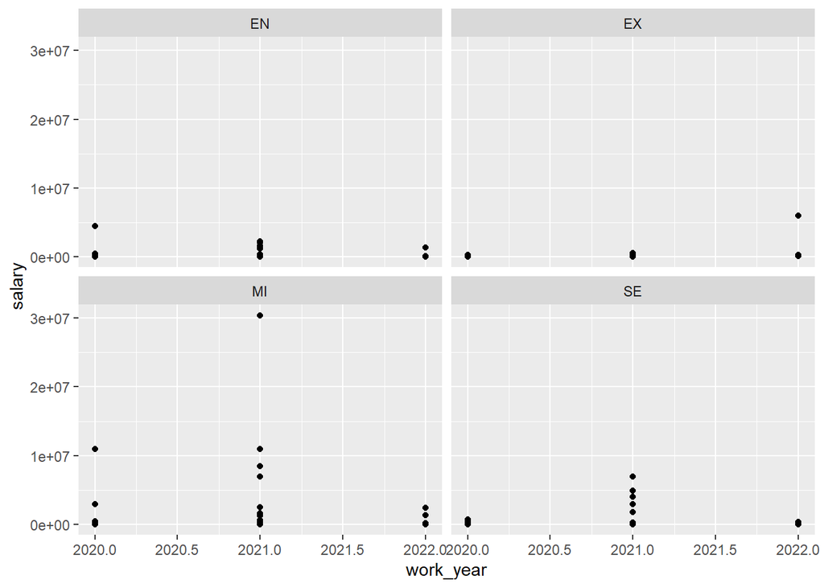

```r
ggplot(df, aes(x = work_year, y = salary)) +
  geom_point() +
  facet_wrap(~ experience_level)
```

Comment: (graph above) This graph is showing the relationship between work year compared to an employees salary. There seems to be a higher salary for those working in 2021, and a lower salary for those in 2022. There is one outliter present in MI.

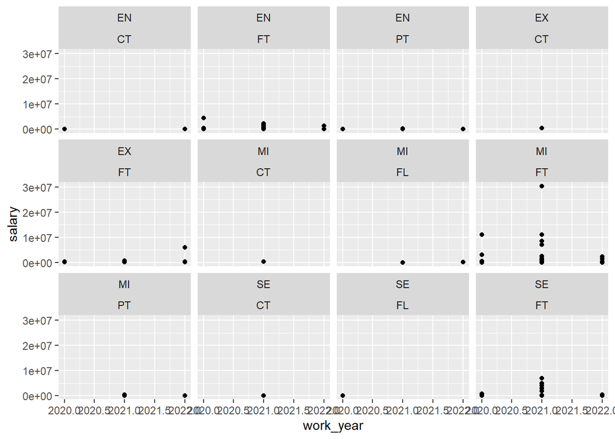

```r
ggplot(df, aes(x = work_year, y = salary)) +
  geom_point() +
  facet_wrap(~ experience_level + employment_type)
```

comment: (graph above)This graph shows how salary varies with work years, split by experience level and employment type. Overall giving insights into the relationship between experience and salary across different categories.

-Make a plot using position =‘dodge’.

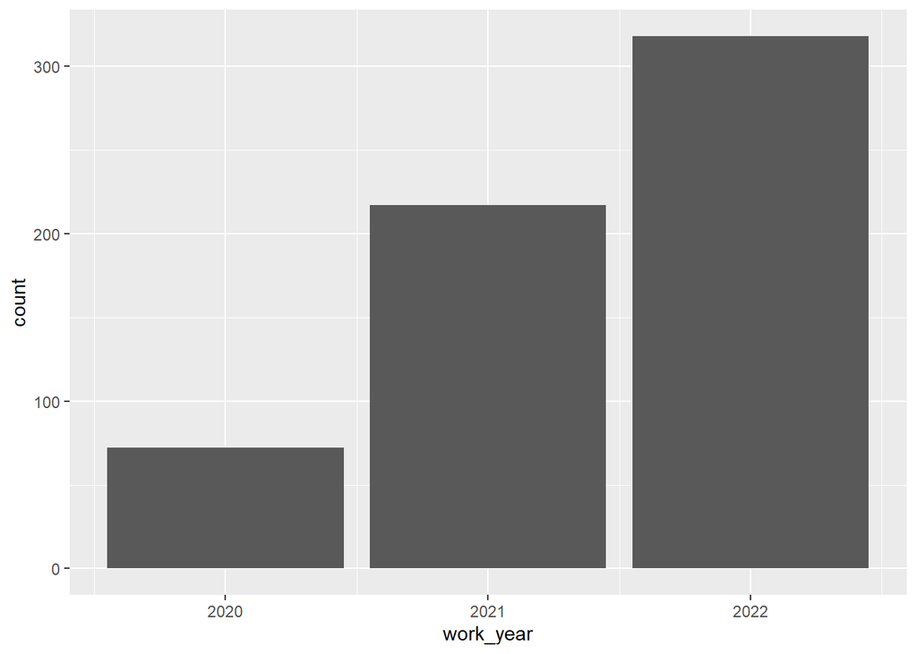

```r
df %>% ggplot()+
  geom_bar(mapping=aes(x = work_year , fill = remote_ratio),
           position = 'dodge')
```

-Make a plot using position =‘fill’.

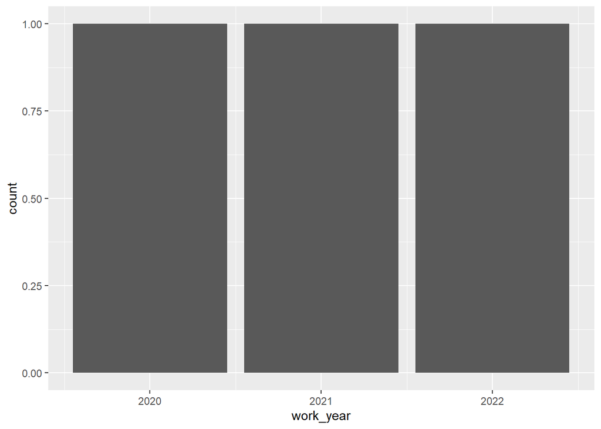

```r
df %>% ggplot()+
  geom_bar(mapping=aes(x = work_year , fill = remote_ratio),
           position = 'fill')
```

-Make a plot using geom_col.

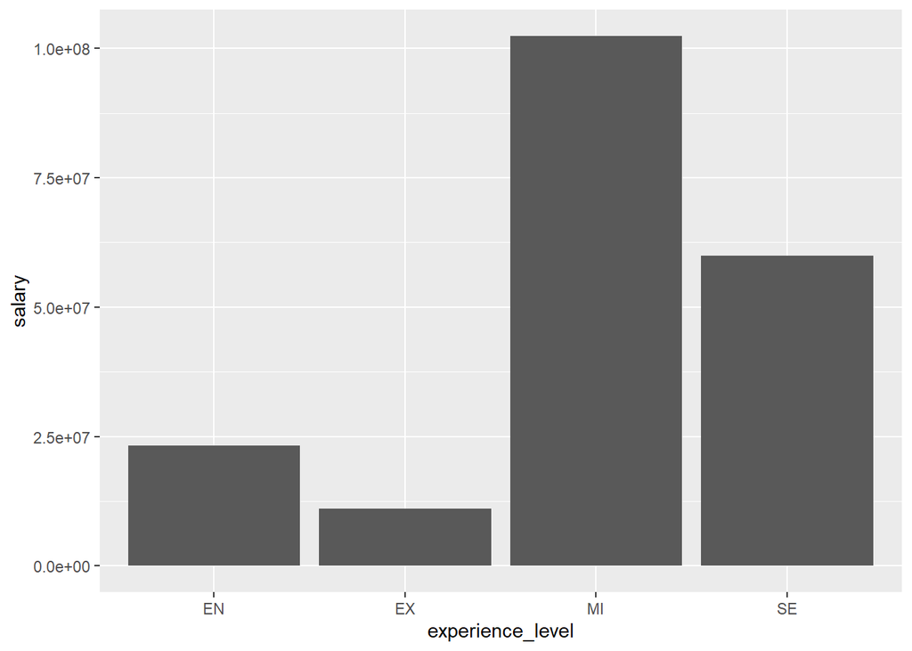

```r
df %>%
  ggplot()+
  geom_col(mapping=aes(x = experience_level, y = salary))
```

comment: This graph shows the relationship between experience level and salary. Each bar on the x-axis represents the different expeirnece levels while the y represents salary. There is no skew in this graph, but alot of variation.

-Change the theme of one of your plots.

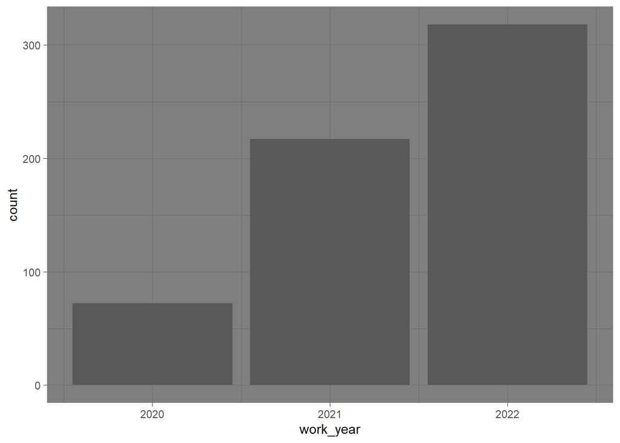

```r
df %>% ggplot()+
  geom_bar(mapping=aes(x = work_year , fill = remote_ratio))+
theme_dark()
```

Make a plot using combo filter + ggplot

```r
df %>%
  filter(work_year == 2020, remote_ratio == 0)
```

```
## # A tibble: 15 × 12
##     ...1 work_year experience_level employment_type job_title             salary
##    <dbl>     <dbl> <chr>            <chr>           <chr>                  <dbl>
##  1     0      2020 MI               FT              Data Scientist        7   e4
##  2     1      2020 SE               FT              Machine Learning Sci… 2.6 e5
##  3     3      2020 MI               FT              Product Data Analyst  2   e4
##  4    10      2020 EN               FT              Data Scientist        4.50e4
##  5    11      2020 MI               FT              Data Scientist        3   e6
##  6    12      2020 EN               FT              Data Scientist        3.5 e4
##  7    20      2020 MI               FT              Machine Learning Eng… 2.99e5
##  8    23      2020 MI               FT              BI Data Analyst       9.8 e4
##  9    24      2020 MI               FT              Lead Data Scientist   1.15e5
## 10    27      2020 SE               FT              Data Engineer         7.20e5
## 11    33      2020 MI               FT              Research Scientist    4.50e5
## 12    42      2020 MI               FT              Machine Learning Inf… 4.40e4
## 13    50      2020 EN               FT              Data Analyst          4.50e5
## 14    66      2020 EN               FT              Data Scientist        4.32e4
## 15    69      2020 SE               FT              Data Scientist        8   e4
## # ℹ 6 more variables: salary_currency <chr>, salary_in_usd <dbl>,
## #   employee_residence <chr>, remote_ratio <dbl>, company_location <chr>,
## #   company_size <chr>
```

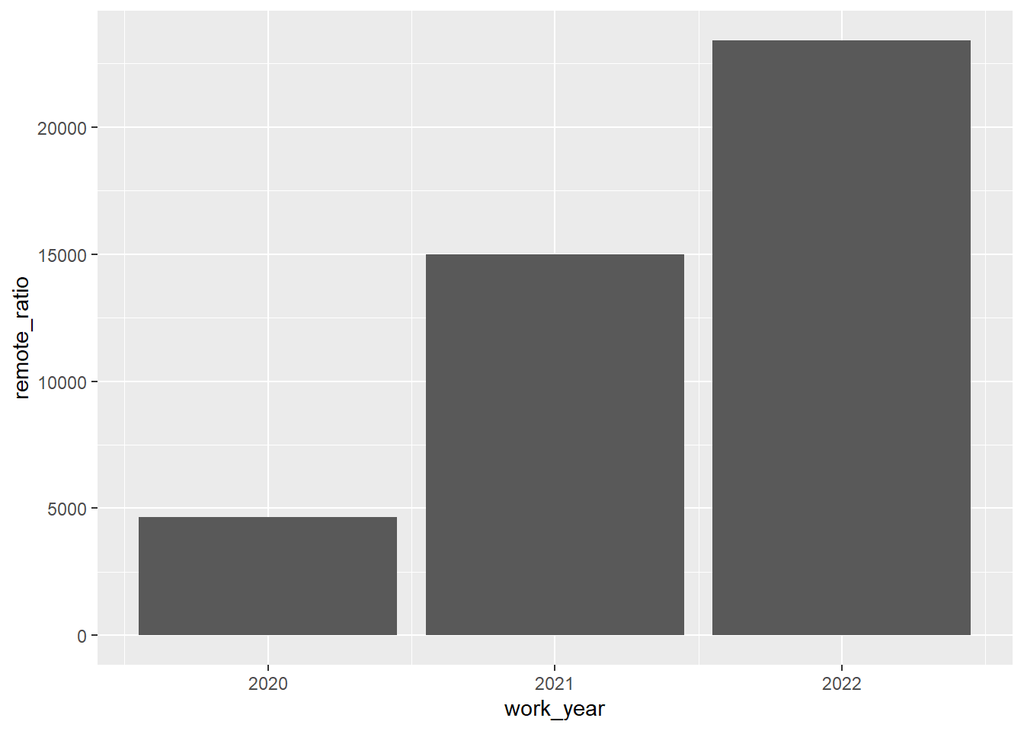

```r
  ggplot(df, aes(x = work_year, y = remote_ratio)) +
  geom_col()
```

-Make a plot using combo group_by + summarise + geom_col

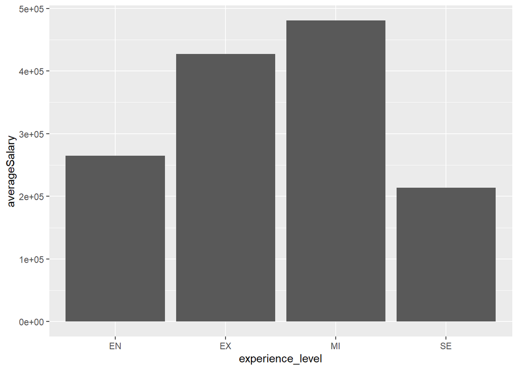

```r
df %>%
  group_by(experience_level) %>%
  summarise(averageSalary = mean(salary, na.rm=TRUE)) %>%
  ggplot()+
  geom_col(mapping=aes(x = experience_level, y = averageSalary))
```

-comment: This graph has alot of different variation and a slight skew left, this shows the relationship between average salary and the correlation to experience level.

```r
gg <- df %>%
  group_by(experience_level) %>%
  summarise(averageSalary = mean(salary, na.rm=TRUE)) %>%
  ggplot()+
  geom_col(mapping=aes(x = experience_level, y = averageSalary))
```